# Colgate Crest

Beatriz Cárdaba

# 1. Resumen y Objetivo

Este informe analiza un caso de negocio mediantes modelos de series temporales. En esta ocasión se estudia a lucha por la cuota de mercado entre la crema dental Colgate de Colgate-Palmolive y la crema dental Crest de Procter y Gamble.

La compañía Crest de Procter y Gamble inrudujo su marta de pasta dentifrica Crest en 1956 cuando Colgate contaba con un casi un 50% de la cuota de mercado. Durante los primeros años de competencia entre las dos formas, COlgate mantuvo su liderazgo en el sector y Crest se estabilizó con una participación en el meracdo de un 15%.

Esta situación cambió en agosto de 1960 cuando el Consejo de Terapéutica Dental de la American Dental Association (ADA) recomendó el dentifrico Crest. Este hecho fue aprovechado por las campañas de Marketing de Crest, que aumentaró notablebente sus ventas mientras se redujeron las de Colgate. Este hecho se considera una intervención de tipo **escalon** .

# DATA

En la base de datos que se va a utilizar en el informe se ecuntran los valores de las ventas semnales de CREST y Colgate desde 1958 hasta 1963. Los datos están agrupados semanalmente, por lo que nos enfrentamos a una serie temporal. En primer lugar establecemos un formato en el que sea sea posible identificar las ventas de cada empresa con cada semana. Dada las caracterísitcas de los modelos que se van a utilizar separamos los datos de Colgate y Crest.

Visualizamos la forma de los datos de Colgate:

```
##            xColgate.Close
## 1958-01-08          0.424
## 1958-01-15          0.482
## 1958-01-22          0.428
## 1958-01-29          0.397
## 1958-02-05          0.352
## 1958-02-12          0.342
```

Visualizamos los datos de Crest

```
##            xCrest.Close
## 1958-01-08        0.108
## 1958-01-15        0.166
## 1958-01-22        0.126
## 1958-01-29        0.115
## 1958-02-05        0.119
## 1958-02-12        0.176
```

Es importante también visualizar mediane gráficos como impactó la recomendación de ADA en el sector.

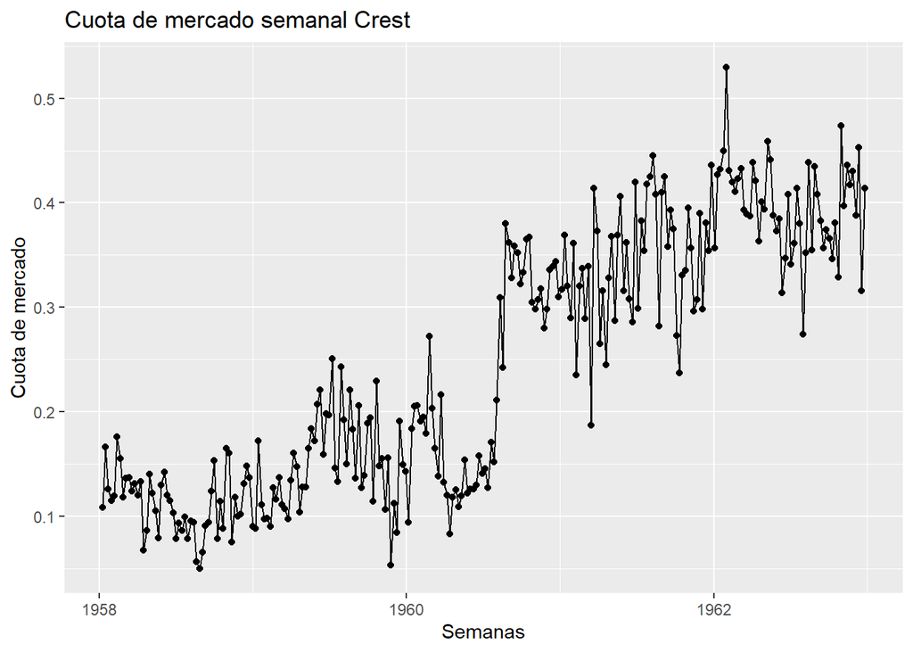

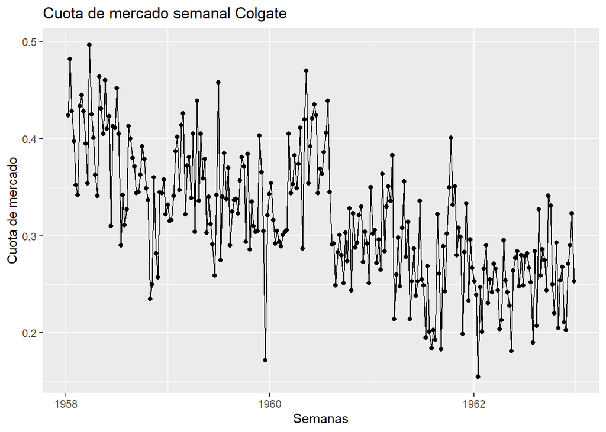

En esta caso se considera escaloón ya que la recomendación de ADA provoca un cambio drástico en los nieveles de ventas de ambas compañias que no vuleven a su estado inical.

Visualizamos el efecto escalón a partir de un determinado momento.

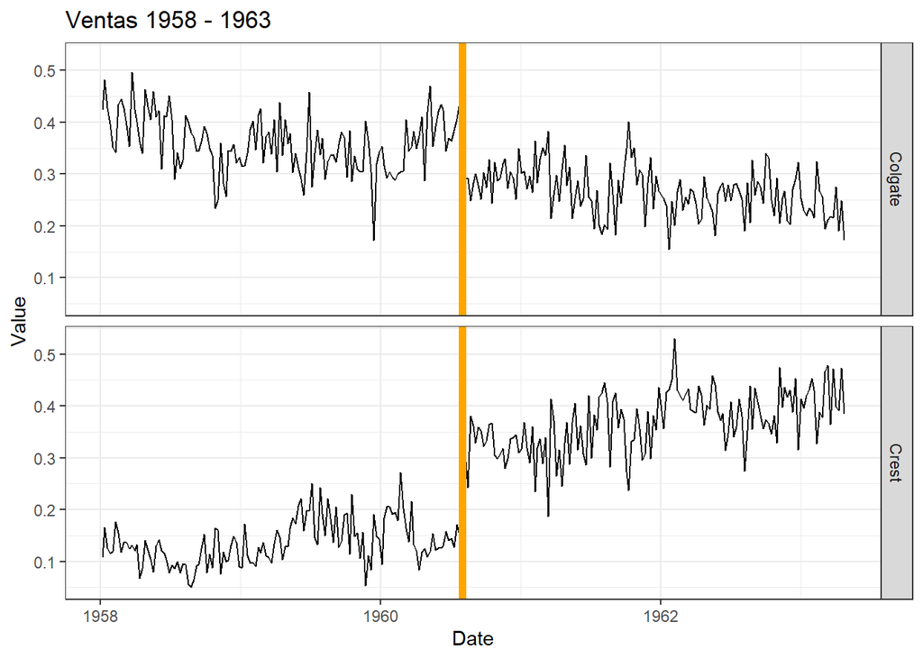

## Autoarima

Hay que definir los modelos ARIMA para cada compañía

### Crest

El modelo ARIMA obtenido para Crest es un (0,1,1). Dicho modelo no tiene estacionalidad. La parte regular tiene 0 como valor de p (número de términos autorregresivos), d es 1 que indica que el número de diferencias y q es 1 que significa el número de retardos del modelo.

### Colgate

El modelo ARIMA obtenido para Colgate es un (0,1,1). Dicho modelo no tiene estacionalidad. La parte regular tiene 0 como valor de p (número de términos autorregresivos), d es 1 que indica que el número de diferencias y q es 1 que significa el número de retardos del modelo.

## Detección de Outliers

El siguiente paso es identificar si se tiene outliers aditivos (que afectan la serie temporal) e innovativos (que afectan el error).

```
##               [,1]       [,2]       [,3]
## ind     135.000000 136.000000 138.000000
## lambda2   3.918954   4.372891   4.005427
```

```
## [1] "No IO detected"
```

Para el caso de Crest se identifica la intervención de ADA como un outlier aditivo (Observación 135). También se encontraron otros outliers aditivos en las observaciones 136 y 138. No se han identificado outliers innovativos. En el caso de Colgate no se detectaron outliers aditivos ni innovativos.

```
## [1] "No AO detected"
```

```
## [1] "No IO detected"
```

Es importante conocer los Outlieres para no confundirlos con los datos de los escalones o los impulsos.

## Modelo de Intervención

Una vez se conoce el modelo ARIMA que se va a usar y los valores Ouliers, se puede realizar el modelo de intervención.

En estos modelos a el valor de la variable Yt, en este caso las ventas, se explica en función de:

— de valores pasados de Yt.

— de acontecimientos aislados ocurridos en momentos concretos, conocidos, que se anticipa hayan podido afectar a la serie Y, en este caso la recomendación de ADA.

— de errores cuya estructura puede aproximarse adecuadamente con un modelo univariante y reducirles a error aleatorio «ruido blanco.

**Modelo de intervención Crest**

Se crea un modelo que estudie la serie temporal de las ventas de Crest en un peridoo teniendo en cuenta que en la observación número 135 se produce un cambio de tendencia (escalón) por la recomendación de ADA y que las observaciónes 136 y 138 corresponden a Outliers

```
##
## Call:
## arimax(x = oCrest, order = c(0, 1, 1), xreg = data.frame(out136 = 1 * (seq(oCrest) ==
##     136), out138 = 1 * (seq(oCrest) == 138)), method = "ML", xtransf = data.frame(ADA.Int = 1 *
##     (seq(oCrest) >= 135)), transfer = list(c(0, 0)))
##
## Coefficients:
##           ma1  out136  out138  ADA.Int-MA0
##       -0.7445  0.0225  0.0768       0.1336
## s.e.   0.0493  0.0432  0.0414       0.0327
##
## sigma^2 estimated as 0.001877:  log likelihood = 445.09,  aic = -882.18
```

El modelo obtiene un AIC de -882 y calcula el coeficiente de la diferenciación de la media autorregresiva -0.7445. Se ha estimado como 0.1336 para la intersección de la incidencia del anuncio de ADA en la serie temporal. Este valor sirve para estimar los efectos de la intervención.

En este gráfico se representa en azul los valores del modelo arimax respecto de la muestra estudiada. Se observa que el modelo sí que se ajusta a las series temporales

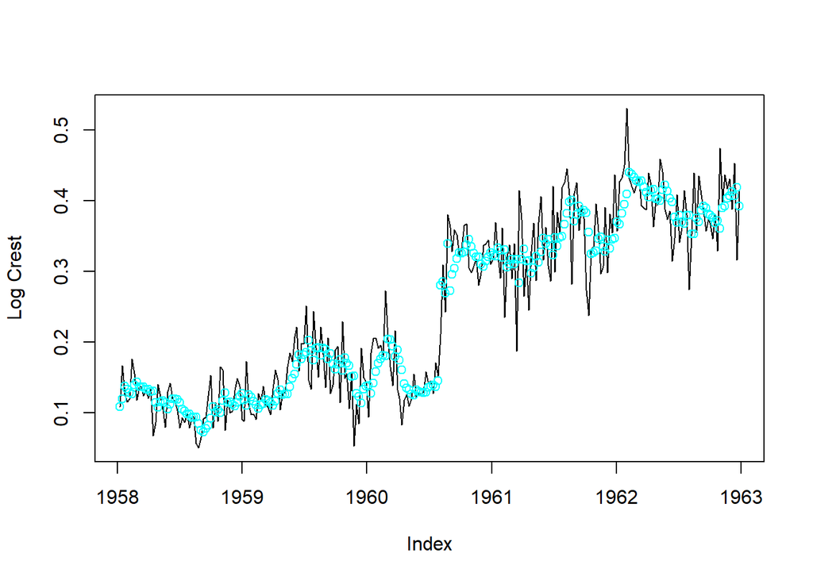

**Modelo de intervención Colgate**

Este modelo estudia la serie temporal de las ventas de Colgate teniendo en cuenta el cambio de tendencia a partir del momento en el que ADA realiza la recomendación del consumo de Crest.

```
##
## Call:
## arimax(x = oColgate, order = c(0, 1, 1), xreg = data.frame(out136 = 1 * (seq(oColgate) ==
##     136), out138 = 1 * (seq(oColgate) == 138)), method = "ML", xtransf = data.frame(ADA.Int = 1 *
##     (seq(oColgate) >= 135)), transfer = list(c(0, 0)))
##
## Coefficients:
##           ma1   out136   out138  ADA.Int-MA0
##       -0.8038  -0.0093  -0.0475      -0.0953
## s.e.   0.0439   0.0463   0.0454       0.0293
##
## sigma^2 estimated as 0.002189:  log likelihood = 425.06,  aic = -842.11
```

El modelo de Colgate obtiene un AIC de -842 y calcula el coeficiente de la diferenciación de de la media autorregresiva de -0.8038. Se ha estimado como -0.0953 para la intersección de la incidencia de ADA en la serie temporal. Este valor sirve para estimar los efectos de la intervención.

Se representa el el siguinente grafico como se adapta el modelo creado a la serie temporal:

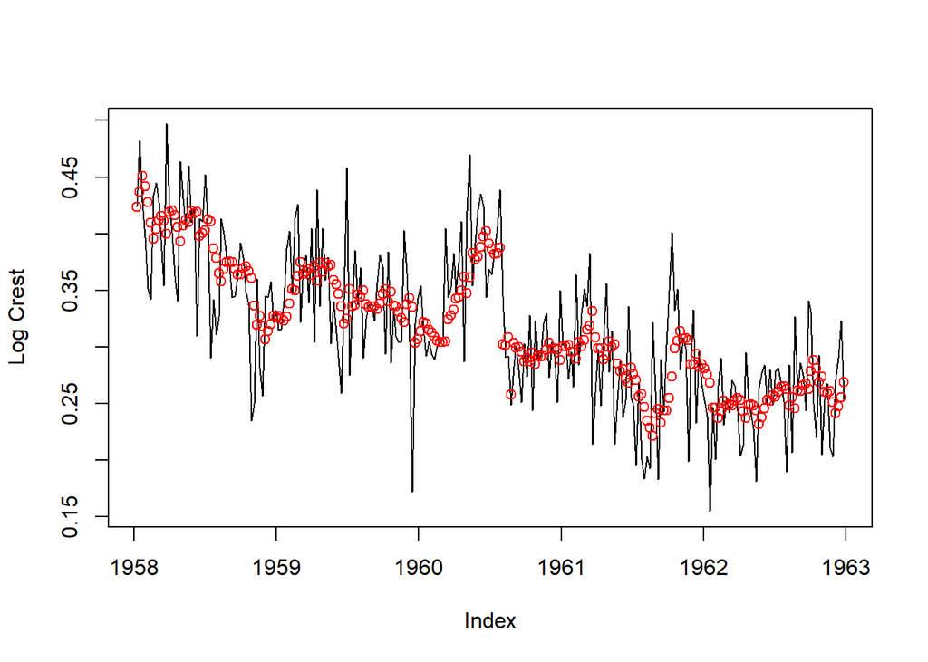

### Outliers de los Modelos de Intervención

```
## [1] "No AO detected"
```

```
## [1] "No IO detected"
```

```
## [1] "No AO detected"
```

```
## [1] "No IO detected"
```

No se detectan Outliers en el modelo de intervención.

### Modelo de función de tranferencia entre las dos cuotas

Se define la función de transferencia con el objetivo de ver si existe una relación dinámica entre ambas series temporales a partir del aumento de ventas de Crest debido a la intervención de ADA.

```
##
## Call:
## arimax(x = as.double(zColgate), order = c(0, 1, 1), include.mean = TRUE, method = "ML",
##     xtransf = zCrest, transfer = list(c(0, 15)))
##
## Coefficients:
##           ma1  xCrest.Close-MA0  xCrest.Close-MA1  xCrest.Close-MA2
##       -0.8343           -0.4961           -0.0466           -0.0370
## s.e.   0.0379            0.0554            0.0558            0.0562
##       xCrest.Close-MA3  xCrest.Close-MA4  xCrest.Close-MA5  xCrest.Close-MA6
##                 0.0153            0.0664           -0.0192            0.0669
## s.e.            0.0567            0.0567            0.0570            0.0572
##       xCrest.Close-MA7  xCrest.Close-MA8  xCrest.Close-MA9  xCrest.Close-MA10
##                -0.0148            0.0068           -0.0244            -0.0208
## s.e.            0.0575            0.0577            0.0577             0.0576
##       xCrest.Close-MA11  xCrest.Close-MA12  xCrest.Close-MA13
##                  0.0217             0.0133             0.0538
## s.e.             0.0582             0.0582             0.0577
##       xCrest.Close-MA14  xCrest.Close-MA15
##                  0.0197            -0.0389
## s.e.             0.0573             0.0568
##
## sigma^2 estimated as 0.001657:  log likelihood = 462.81,  aic = -891.63
```

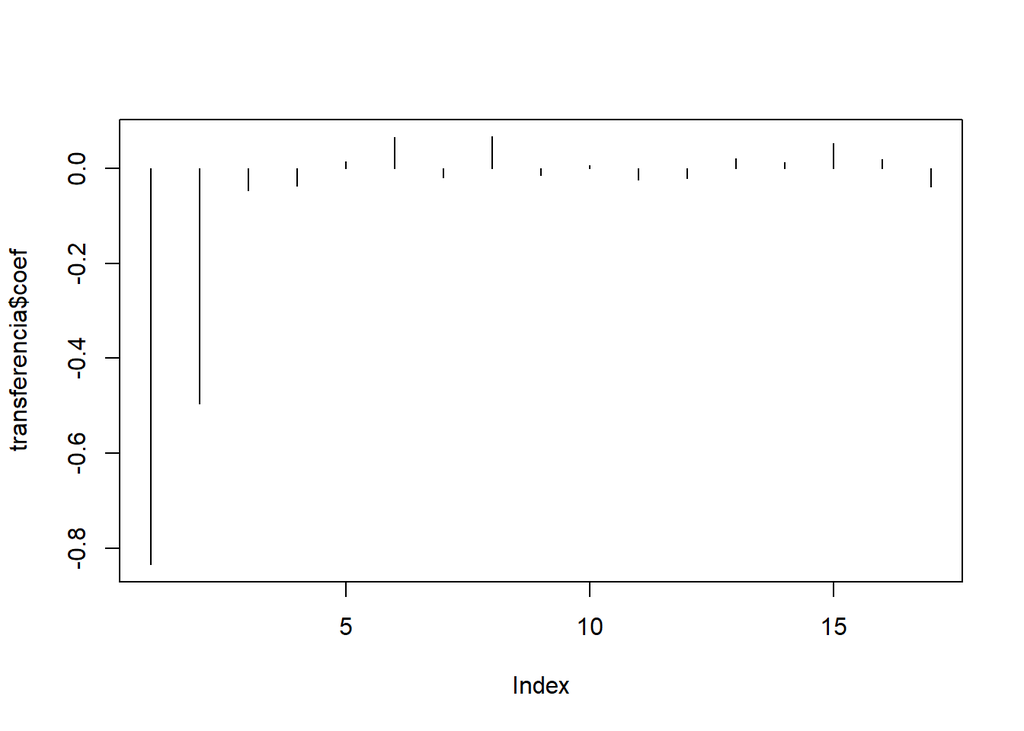

```
##
## Call:
## arimax(x = zColgate, order = c(0, 1, 1), include.mean = TRUE, fixed = c(NA,
##     NA, 0, 0, NA), method = "ML", xtransf = zCrest, transfer = list(c(1, 2)))
##
## Coefficients:
##           ma1  xCrest.Close-AR1  xCrest.Close-MA0  xCrest.Close-MA1
##       -0.8002            0.2815                 0                 0
## s.e.   0.0496            0.3868                 0                 0
##       xCrest.Close-MA2
##                -0.0988
## s.e.            0.0649
##
## sigma^2 estimated as 0.002238:  log likelihood = 445.07,  aic = -884.13
```

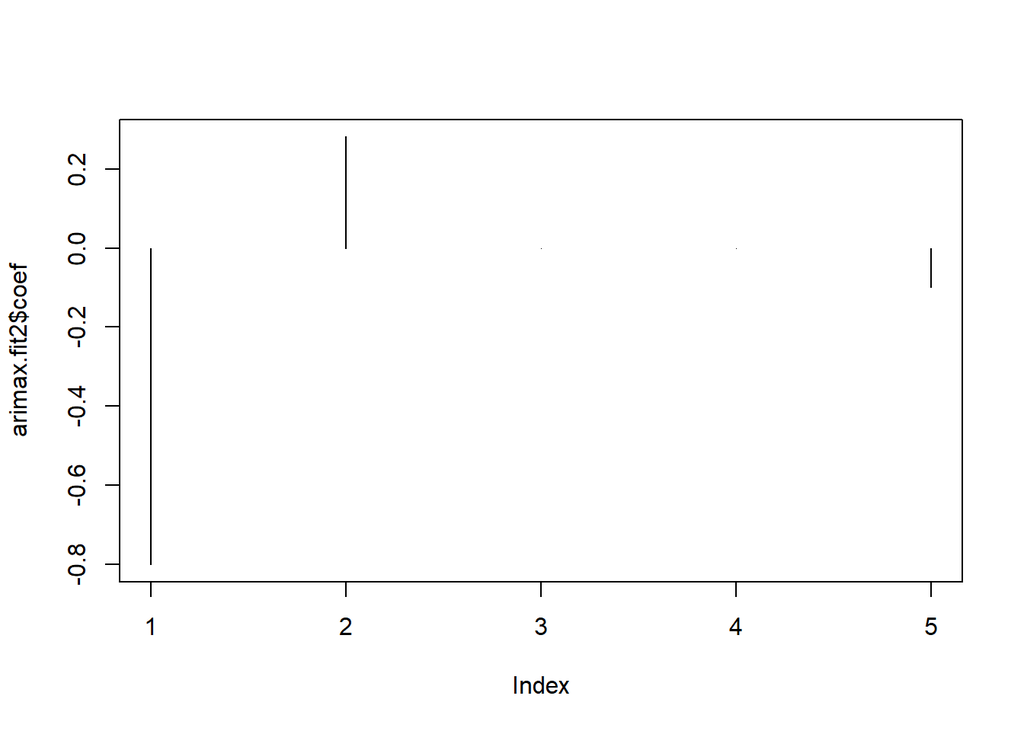

# Predicción.

Se realiza la representación de los valores estimados para las ventas de Crest y Colgate en 1963.

*Predicción de Crest*

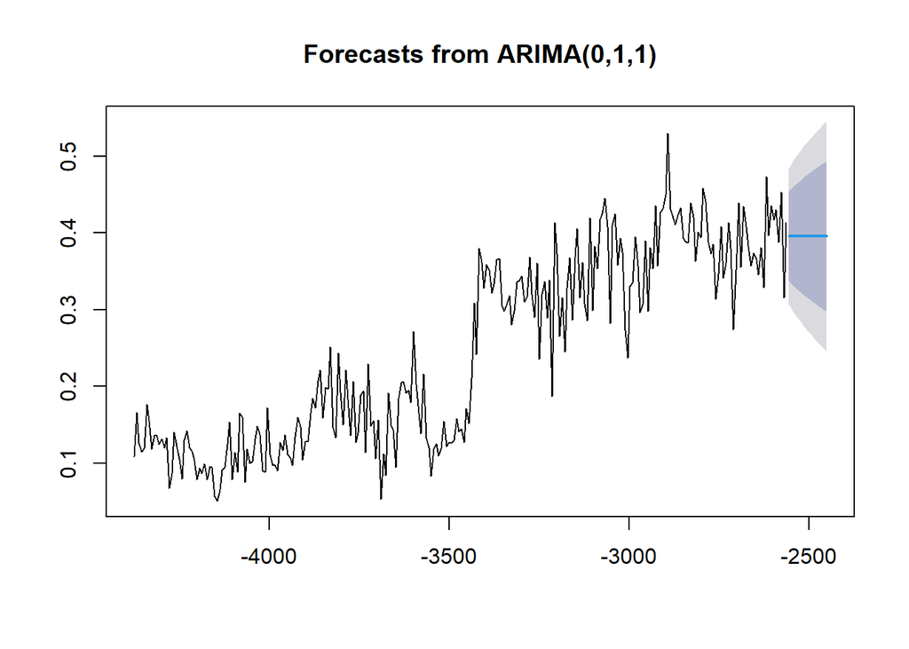

*Predicción de Colgate*

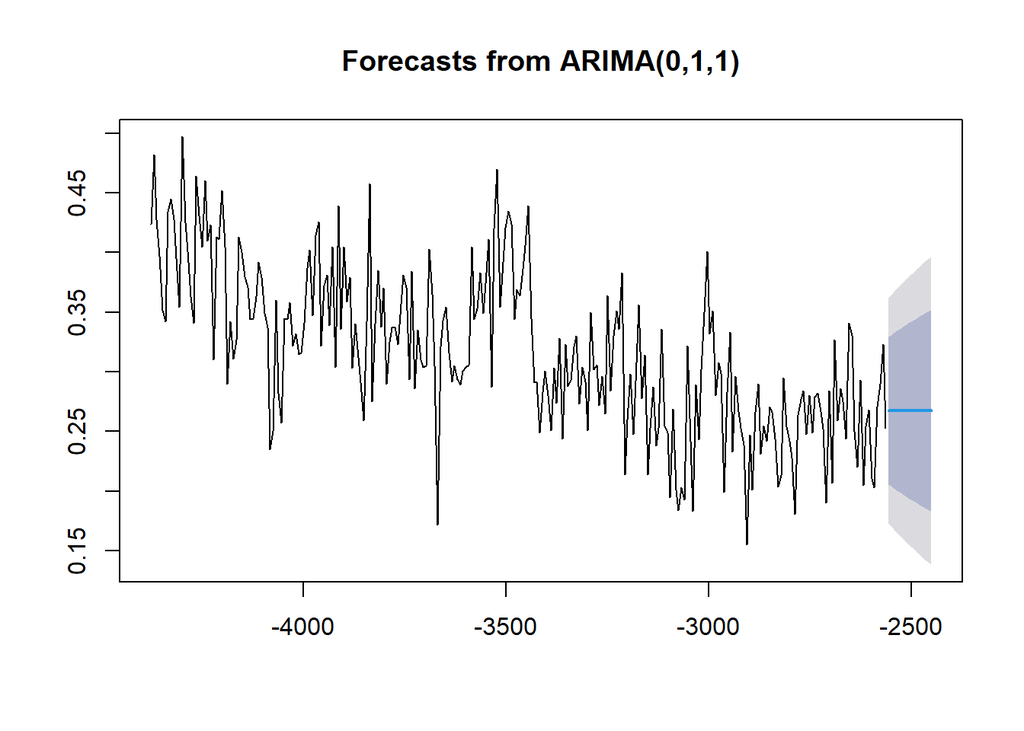

## Conclusión

Como se ha podido observar en los diferentes modelos es indiscutible la repercusión que tuvo la recomendación de ADA sobre laos beneficios del uso de Crest. Todos los modelos coinciden en que esta aumentó sus ventas mientras que Colgate las disminuyó.